# modelplotr: Gain & Lift

## Response plot

One of the easiest to explain evaluation plots is the response plot. It simply plots the percentage of target class observations per decile. It can be used to answer the following business question:

*When we apply the model and select decile X, what is the expected % of target class observations in that decile?*

The plot has one reference line: The % of target class cases in the total set. It looks like this:

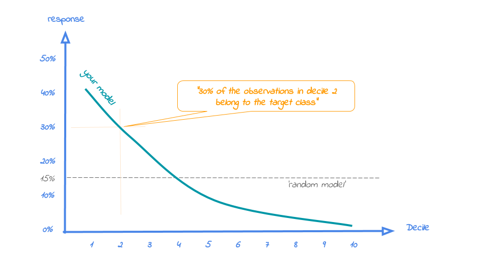

A good model starts with a high response value in the first decile(s) and suddenly drops quickly towards 0 for later deciles. This indicates good differentiation between target class members - getting high model scores - and all other cases. An interesting point in the plot is the location where your model’s line intersects the random model line. From that decile onwards, the % of target class cases is lower than a random selection of cases would hold.

To generate the response plot for our term deposit model, wcall the function `plot_response()`. Let’s immediately highlight the plot to have the interpretation of the response plot at decile 1 added to the plot:

```
##
## Plot annotation:
## - When we select decile 1 according to model XGBoost in dataset test data the % of term.deposit cases in the selection is 61%.
##
##
```

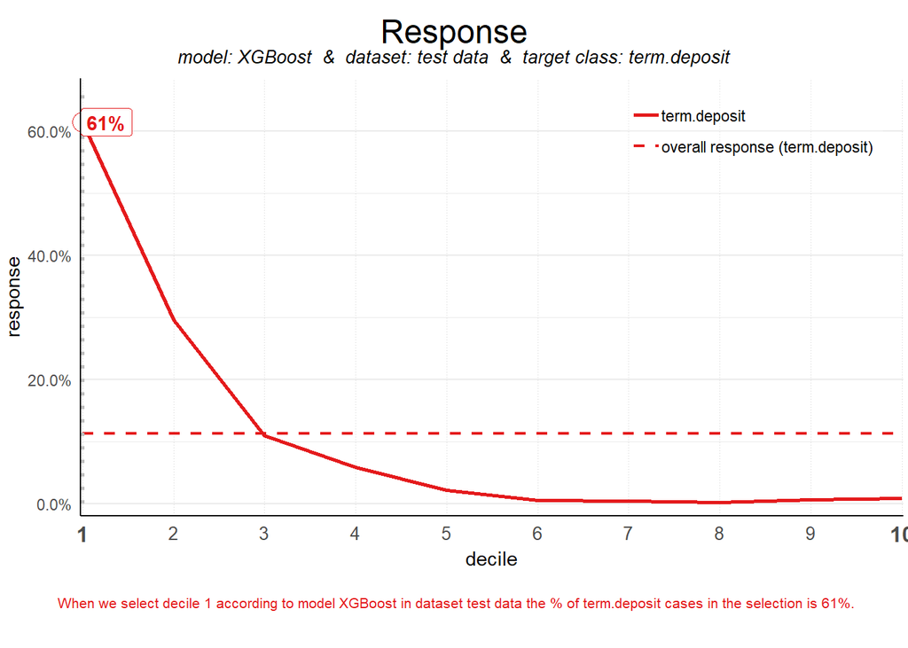

```r
# plot the response plot and annotate the plot at decile = 1
plot_response(highlight_decile = 1)
```

```r
##
## Plot annotation:
## - When we select decile 1 according to model XGBoost in dataset test data the % of term.deposit cases in the selection is 61%.
##
##
```